# Reproducible Research: Peer Assessment 1

## Loading required libraries

```r
#Check and install libraries if neccessary
if(!"dplyr" %in% rownames(installed.packages()))
        install.packages("dplyr")
library(dplyr)
if(!"lubridate" %in% rownames(installed.packages()))
        install.packages("lubridate")
library(lubridate)
if(!"ggplot2" %in% rownames(installed.packages()))
        install.packages("ggplot2")
library(ggplot2)
if(!"stringr" %in% rownames(installed.packages()))
        install.packages("stringr")
library(stringr)
if(!"scales" %in% rownames(installed.packages()))
        install.packages("scales")
library(scales)
library(knitr)
```

## Loading and preprocessing the data

Downloading data from course web site and reading it.

```r
if(!file.exists("activity.csv")){
        if(!file.exists("repdata_data_activity.zip")) #check if original file is already downloaded
        {
                download.file('https://d396qusza40orc.cloudfront.net/repdata%2Fdata%2Factivity.zip',
                                "repdata_data_activity.zip",
                                mode = "wb")
        }
        unzip("repdata_data_activity.zip")
}

activityData <- read.csv("activity.csv",sep=",", na.strings = "NA", stringsAsFactors = FALSE,
                       colClasses = c("numeric","character","character"))
```

Transforming intervals to timestapms (e.g. 805 to 08:05) and getting week days for each date.

```r
activityData <- activityData %>%
        mutate(
                date=ymd(date), #convert text to date
                interval=str_pad(interval,4,pad="0"), #add leading zeroes to interval (hours or minutes)
                interval=sub( '(?<=.{2})', ':', interval, perl=TRUE ), #insert separator between hours and minutes
                #interval=parse_date_time(interval,"hm")
                interval = as.POSIXct(interval, format='%H:%M',tz="UTC"),
                weekDay = factor(as.POSIXlt(date)[["wday"]],labels=c("Sun","Mon","Tue","Wed","Thu","Fri","Sat"))
                )
```

## What is mean total number of steps taken per day?

Calculating total number of steps per day.

```r
#summarize total number of steps per day
activitySummary<-activityData %>%
        group_by (date,weekDay) %>%
        summarize (totalSteps=sum(steps), numNA=sum(is.na(steps)) )
```

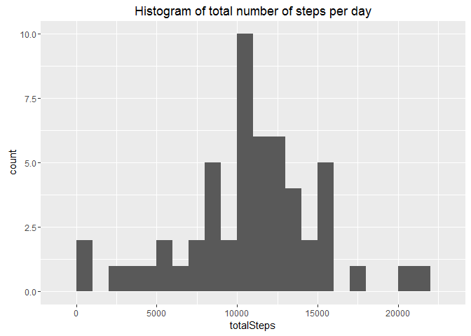

```r
#draw histogramm
ggplot(data=activitySummary, aes(totalSteps)) +
        geom_histogram(binwidth=1000) +
        ggtitle("Histogram of total number of steps per day")
```

```r
options(scipen = 6) #set number of digits that can be printed before switching to scientific notation.
```

Calculating mean and total number of steps per day.

```r
meanTotalSteps <- round(mean(activitySummary$totalSteps,na.rm=TRUE),2)
meanTotalSteps
```

```
## [1] 10766.19
```

```r
medianTotalSteps<-median(activitySummary$totalSteps,na.rm=TRUE)
medianTotalSteps
```

```
## [1] 10765
```

Mean total number of steps taken per day is 10766.19.  
Median total number of steps taken per day is 10765.

## What is the average daily activity pattern?

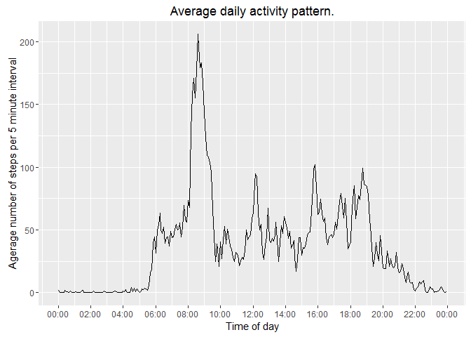

```r
intervalActivitySummary<-activityData %>%
        group_by (interval) %>%
        summarize (avgSteps=mean(steps,na.rm=TRUE), numNA=sum(is.na(steps)) )

ggplot(data = intervalActivitySummary, aes(interval,avgSteps)) +
        geom_line()+
        scale_x_datetime(breaks = date_breaks("120 mins"), labels = date_format("%H:%M")) +
        ylab("Agerage number of steps per 5 minute interval") +
        xlab("Time of day")+
        ggtitle("Average daily activity pattern.")
```

```r
maxAvgSteps<-max(intervalActivitySummary$avgSteps) # get peak avgSteps value
maxAvgStepsInterval<-intervalActivitySummary %>% filter(avgSteps==maxAvgSteps) #find peak interval
periodStart<-format(maxAvgStepsInterval$interval,'%H:%M') #get start of period
periodEnd<-format(maxAvgStepsInterval$interval+300,'%H:%M') #calculate end of period
```

The maximum number of steps is in the interval between 08:35 and 08:40.

## Imputing missing values

```r
totalMissing<-nrow(activityData %>% filter(is.na(steps)))
totalMissing
```

```
## [1] 2304
```

The total number of missing values is 2304 (out of 17568). Let’s see how missing values are distributed among the dates.

```r
weekDayActivitySummary<-activityData %>%
        filter(is.na(steps)==TRUE) %>%
        group_by(date,weekDay) %>%
        summarize(numNA=sum(is.na(steps)))
#kable(weekDayActivitySummary) #removed since kable looks bad in md files in github
weekDayActivitySummary
```

```
## Source: local data frame [8 x 3]
## Groups: date [?]
##
##         date weekDay numNA
##       (time)  (fctr) (int)
## 1 2012-10-01     Mon   288
## 2 2012-10-08     Mon   288
## 3 2012-11-01     Thu   288
## 4 2012-11-04     Sun   288
## 5 2012-11-09     Fri   288
## 6 2012-11-10     Sat   288
## 7 2012-11-14     Wed   288
## 8 2012-11-30     Fri   288
```

As we can see there are a number of days when all 288 records are missing. That means that average over interval will be fair. Moreover, there are no particular days of week when too many values are missing.

Let’s see if we need to take weekday into account. Let’s see if moving pattern differs among the week days.

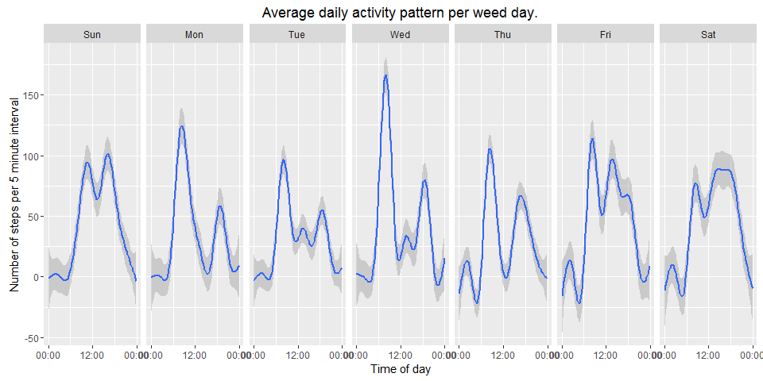

```r
filteredData<-activityData%>%filter(!is.na(steps))

ggplot(data = filteredData, aes(interval,steps)) +
        geom_smooth() +
        facet_grid(.~weekDay) +
        scale_x_datetime(breaks = date_breaks("720 mins"), labels = date_format("%H:%M")) +
        ylab("Number of steps per 5 minute interval") +
        xlab("Time of day") +
        ggtitle("Average daily activity pattern per weed day.")
```

As we see, Friday, Saturday and Sunday have somewhat similar pattern, that differs significantly from other days. So, let’s average missing values on per interval, per weekday basis.

```r
#calculate averages per interval per weekday
theAverages<-filteredData %>%
        group_by(interval,weekDay) %>%
        summarize(avgSteps=round(mean(steps)))%>%
        ungroup()

#function that returns correct value for any missing interval/weekday
# or returns current value if value is not missing
getCorrectAverage<-function(naRow,theAverages)
{
        if(is.na(naRow[1,"steps"])) #check if value is missing
        {
                avgValue<-theAverages %>% #selecting appropriate value from pre-calculated averages
                        filter(interval==naRow[1,"interval"],
                               weekDay==naRow[1,"weekDay"]) %>%
                        select(avgSteps)
                as.numeric(avgValue["avgSteps"])
        }else
                naRow[1,"steps"]
}

#make a copy of data
filledActivityData<-activityData

#set missing values
for(i in c(1:nrow(activityData)))
{
        filledActivityData$steps[i]<-getCorrectAverage(activityData[i,],theAverages)
}
```

### What is the new mean total number of steps taken per day?

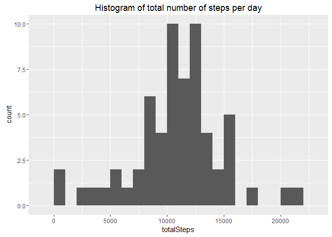

```r
#summarize total number of steps per day
activitySummary<-filledActivityData %>%
        group_by (date,weekDay) %>%
        summarize (totalSteps=sum(steps),numNA=sum(is.na(steps)) )

#draw histogramm
ggplot(data=activitySummary, aes(totalSteps)) +
        geom_histogram(binwidth=1000) +
        ggtitle("Histogram of total number of steps per day")
```

```r
options(scipen = 6) #set number of digits that can be printed before switching to scientific notation.

newMeanTotalSteps<- round(mean(activitySummary$totalSteps,na.rm=TRUE),2)
newMeanTotalSteps
```

```
## [1] 10821.1
```

```r
newMedianTotalSteps<-median(activitySummary$totalSteps,na.rm=TRUE)
newMedianTotalSteps
```

```
## [1] 11015
```

New mean total number of steps taken per day is 10821.1 (was 10766.19).  
New median total number of steps taken per day is 11015 (was 10765).  
As we see, the average and median of the total number of steps per day increased over the initial measurement.

## Are there differences in activity patterns between weekdays and weekends?

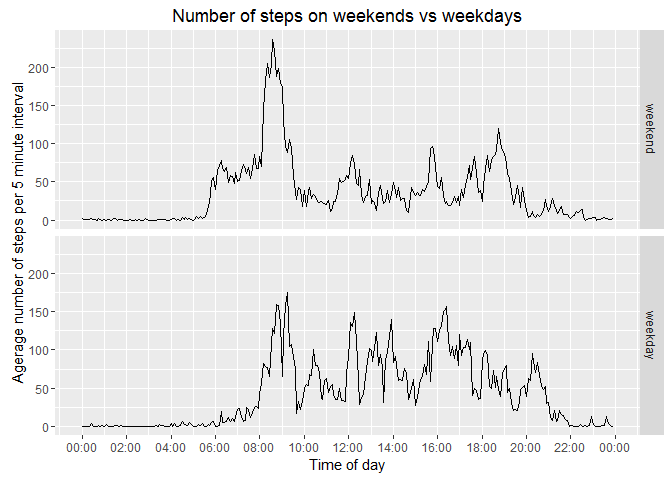

```r
#add is_weekend factor variable
filledActivityData<-filledActivityData %>%
        mutate(
                is_weekend=as.numeric(weekDay=='Sat'|weekDay=='Sun'),
                is_weekend=factor(is_weekend,labels=c("weekend","weekday"))
                )
#summarize data by interval and is_weekend factor.
intervalActivitySummary<-filledActivityData %>%
        group_by(interval, is_weekend) %>%
        summarize( avgSteps=mean(steps))

#draw 2 daily activity graphs.
ggplot(data = intervalActivitySummary, aes(interval,avgSteps)) +
        geom_line()+
        facet_grid(is_weekend~.)+
        scale_x_datetime(breaks = date_breaks("120 mins"), labels = date_format("%H:%M")) +
        ylab("Agerage number of steps per 5 minute interval") +
        xlab("Time of day") +
        ggtitle("Number of steps on weekends vs weekdays")
```